# IS605_HW11

Daina Bouquin

April 14, 2016

```r
library(ggplot2)
```

Using R’s lm function, perform regression analysis and measure the significance of the independent variables for the below two data sets. In the first case, you are evaluating the statement that we hear that Maximum Heart Rate of a person is related to their age by the following equation:
$$MaxHR = 220 − Age$$

#### 1. Perform a linear regression analysis fitting Max Heart Rate to Age using the `lm` function in R. What is the resulting equation? Is the effect of Age on Max HR significant? What is the significance level? Please also plot the fitted relationship between Max HR and Age.

```r
Age   <- c(18, 23, 25, 35, 65, 54, 34, 56, 72, 19, 23, 42, 18, 39, 37)
MaxHR <- c(202, 186, 187, 180, 156, 169, 174, 172, 153, 199, 193, 174, 198, 183, 178)
HR_data <- data.frame(Age,MaxHR)

# use lm() to perform a linear regression analysis
HR_data_fit <- lm(MaxHR ~ Age, data = HR_data)
HR_data_fit$coefficients
```

```
## (Intercept)         Age
## 210.0484584  -0.7977266
```

```r
# is the model significant?
# "We reject the null hypothesis if this probability is lower than a significance threshold (typically 0.01)"
model_summary <- summary(HR_data_fit)
model_summary # p-value much lower than 0.01
```

```
##
## Call:
## lm(formula = MaxHR ~ Age, data = HR_data)
##
## Residuals:
##     Min      1Q  Median      3Q     Max
## -8.9258 -2.5383  0.3879  3.1867  6.6242
##
## Coefficients:
##              Estimate Std. Error t value Pr(>|t|)
## (Intercept) 210.04846    2.86694   73.27  < 2e-16 ***
## Age          -0.79773    0.06996  -11.40 3.85e-08 ***
## ---
## Signif. codes:  0 '***' 0.001 '**' 0.01 '*' 0.05 '.' 0.1 ' ' 1
##
## Residual standard error: 4.578 on 13 degrees of freedom
## Multiple R-squared:  0.9091, Adjusted R-squared:  0.9021
## F-statistic:   130 on 1 and 13 DF,  p-value: 3.848e-08
```

##### Therefore the resulting equation is $MaxHR = 210.0485 - 0.7977Age$ and we reject the null hypothesis

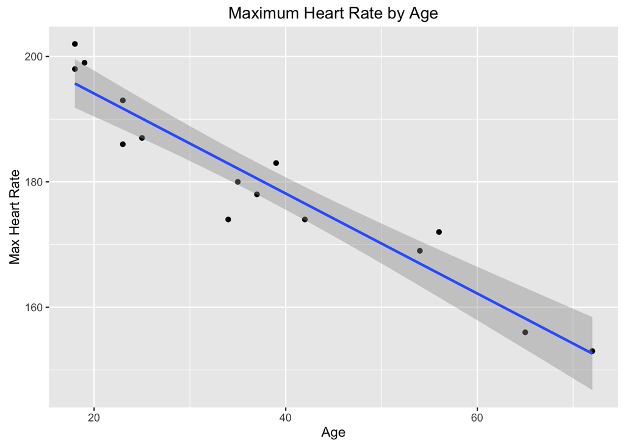

```r
# plot the fitted relationship
# http://docs.ggplot2.org/current/geom_smooth.html
ggplot(HR_data, aes(Age, MaxHR)) +
  geom_point(aes(y=MaxHR)) +
  stat_smooth(method = lm, level = 0.95) +
  xlab("Age") + ylab("Max Heart Rate") +
  ggtitle("Maximum Heart Rate by Age")
```

#### 2. Using the [Auto data set from Assignment 5](https://raw.githubusercontent.com/dbouquin/IS_605/master/IS605_HW5/auto-mpg.data) perform a Linear Regression analysis using mpg as the dependent variable and the other 4 (displacement, horsepower, weight, acceleration) as independent variables. What is the final linear regression fit equation? Which of the 4 independent variables have a significant impact on mpg? What are their corresponding significance levels? What are the standard errors on each of the coefficients?

#### Please perform this experiment in two ways. First take any random 40 data points from the entire auto data sample and perform the linear regression fit and measure the 95% confidence intervals. Then, take the entire data set (all 392 points) and perform linear regression and measure the 95% confidence intervals. Please report the resulting fit equation, their significance values and confidence intervals for each of the two runs.

```r
# read in the auto-data from assignment 5 and check its strucuture
download.file("https://raw.githubusercontent.com/dbouquin/IS_605/master/IS605_HW5/auto-mpg.data", "auto-mpg.data", method="curl")
auto_data <- read.table('auto-mpg.data',
                        col.names=c('disp', 'hp', 'wt', 'acc', 'mpg'))
str(auto_data)
```

```
## 'data.frame':    392 obs. of  5 variables:
##  $ disp: num  307 350 318 304 302 429 454 440 455 390 ...
##  $ hp  : num  130 165 150 150 140 198 220 215 225 190 ...
##  $ wt  : num  3504 3693 3436 3433 3449 ...
##  $ acc : num  12 11.5 11 12 10.5 10 9 8.5 10 8.5 ...
##  $ mpg : num  18 15 18 16 17 15 14 14 14 15 ...
```

```r
# analyze the random sample of 40 first. Use sample() and set.seed()
set.seed(10)
auto_sample <- auto_data[sample(nrow(auto_data), 40),]

# create the model
m_auto_sample <- lm(mpg ~ disp + hp + wt + acc, data = auto_sample)
summary(m_auto_sample)
```

```
##
## Call:
## lm(formula = mpg ~ disp + hp + wt + acc, data = auto_sample)
##
## Residuals:
##     Min      1Q  Median      3Q     Max
## -7.2563 -2.6450 -0.3425  2.2191 12.2042
##
## Coefficients:
##              Estimate Std. Error t value Pr(>|t|)
## (Intercept) 44.117698  10.879547   4.055 0.000266 ***
## disp        -0.023242   0.025681  -0.905 0.371646
## hp          -0.006429   0.075464  -0.085 0.932590
## wt          -0.005408   0.003029  -1.785 0.082860 .
## acc          0.076267   0.502775   0.152 0.880301
## ---
## Signif. codes:  0 '***' 0.001 '**' 0.01 '*' 0.05 '.' 0.1 ' ' 1
##
## Residual standard error: 4.502 on 35 degrees of freedom
## Multiple R-squared:  0.7566, Adjusted R-squared:  0.7288
## F-statistic:  27.2 on 4 and 35 DF,  p-value: 2.597e-10
```

```r
m_auto_sample$coefficients
```

```
##  (Intercept)         disp           hp           wt          acc
## 44.117697855 -0.023241502 -0.006429309 -0.005408394  0.076266690
```

```r
# check to see if any of the variables have a significant impact on mpg
# Is p < 0.05? No, none have a significant impact (True == significant)
summary(m_auto_sample)$coefficients[2:5,4] < 0.05
```

```
##  disp    hp    wt   acc
## FALSE FALSE FALSE FALSE
```

```r
# display the significance levels
summary(m_auto_sample)$coefficients[2:5,4]
```

```
##       disp         hp         wt        acc
## 0.37164648 0.93258986 0.08286011 0.88030124
```

```r
# display the standard error
summary(m_auto_sample)$coefficients[2:5,2]
```

```
##        disp          hp          wt         acc
## 0.025680853 0.075463572 0.003029185 0.502774852
```

Given the very low p-value, we can reject the null hypothesis. The resulting equation is as follows:
$$mpg = 44.12 - 0.02 displacement - 0.006 horsepower - 0.005 weight + 0.076 acceleration$$

Perform the analysis again with the full dataset:

```r
m_auto <- lm(mpg ~ disp + hp + wt + acc, data = auto_data)
summary(m_auto)
```

```
##
## Call:
## lm(formula = mpg ~ disp + hp + wt + acc, data = auto_data)
##
## Residuals:
##     Min      1Q  Median      3Q     Max
## -11.378  -2.793  -0.333   2.193  16.256
##
## Coefficients:
##               Estimate Std. Error t value Pr(>|t|)
## (Intercept) 45.2511397  2.4560447  18.424  < 2e-16 ***
## disp        -0.0060009  0.0067093  -0.894  0.37166
## hp          -0.0436077  0.0165735  -2.631  0.00885 **
## wt          -0.0052805  0.0008109  -6.512  2.3e-10 ***
## acc         -0.0231480  0.1256012  -0.184  0.85388
## ---
## Signif. codes:  0 '***' 0.001 '**' 0.01 '*' 0.05 '.' 0.1 ' ' 1
##
## Residual standard error: 4.247 on 387 degrees of freedom
## Multiple R-squared:  0.707,  Adjusted R-squared:  0.704
## F-statistic: 233.4 on 4 and 387 DF,  p-value: < 2.2e-16
```

```r
m_auto$coefficients
```

```
##  (Intercept)         disp           hp           wt          acc
## 45.251139699 -0.006000871 -0.043607731 -0.005280508 -0.023147999
```

```r
# check to see if any of the variables have a significant impact on mpg
# Is p < 0.05? True == significant impact
summary(m_auto)$coefficients[2:5,4] < 0.05
```

```
##  disp    hp    wt   acc
## FALSE  TRUE  TRUE FALSE
```

```r
# display the significance levels
summary(m_auto)$coefficients[2:5,4]
```

```
##         disp           hp           wt          acc
## 3.716584e-01 8.848982e-03 2.302545e-10 8.538765e-01
```

```r
# display the standard error
summary(m_auto)$coefficients[2:5,2]
```

```
##         disp           hp           wt          acc
## 0.0067093055 0.0165734633 0.0008108541 0.1256011622
```

Given the very low p-value, we can reject the null hypothesis. The resulting equation is as follows:
$$mpg = 45.25 - 0.006 displacement - 0.044 horsepower - 0.005 weight - 0.023 acceleration$$
You can see from the two models that the standard error decreased as we increased the size of the dataset used to create the model.